# Progetto Statistica descrittiva

Davide Cannizzaro

2025-05-19

```r
library(dplyr)
library(knitr)
library(ggplot2)
library(moments)


#preleviamo il dataset
dati <- read.csv("realestate_texas.csv", sep = ",", fileEncoding = "UTF-8")
N <- dim(dati)[1]
```

# 1. Analisi delle variabili.

Identifica e descrivi il tipo di variabili statistiche presenti nel dataset.  
Valuta come gestire le variabili che sottintendono una dimensione tempo e commenta sul tipo di analisi che può essere condotta su ciascuna variabile.

- Variabile: city
  - Tipo: Categorica - Nominale
  - Significato: Città di riferimento per i dati di vendita.
  - Valori Possibili: Nomi delle città.
  - Insight: Confronto performance mercato tra aree geografiche.
- Variabile: year
  - Tipo: Numerica - Continua (da considerare come Categorica - Ordinale)
  - Significato: Anno in cui i dati sono stati registrati.
  - Valori Possibili: Numeri interi.
  - Insight: Analisi tendenze temporali, stagionalità annuale.
- Variabile: month
  - Tipo: Categorica - Ordinale
  - Significato: Mese di riferimento dei dati.
  - Valori Possibili: Numeri dei mesi (Gennaio, 1).
  - Insight: Analisi tendenze temporali, stagionalità intra-annuali
- Variabile: sales
  - Tipo: Numerica - Discreta
  - Significato: Numero totale di vendite immobiliari nel periodo.
  - Valori Possibili: Interi non negativi.
  - Insight: Misura dell’attività complessiva del mercato.
- Variabile: volume
  - Tipo: Numerica - Continua
  - Significato: Valore totale delle vendite (milioni di $).
  - Valori Possibili: Reali non negativi.
  - Insight: Dimensione economica del mercato immobiliare.
- Variabile: median_price
  - Tipo: Numerica - Continua
  - Significato: Prezzo mediano di vendita (in $).
  - Valori Possibili: Reali non negativi.
  - Insight: Indicatore robusto dei prezzi tipici nel tempo.
- Variabile: listings
  - Tipo: Numerica - Discreta
  - Significato: Numero totale di annunci attivi a fine mese.
  - Valori Possibili: Interi non negativi.
  - Insight: Rappresenta l’offerta di immobili sul mercato.
- Variabile: months_inventory
  - Tipo: Numerica - Continua
  - Significato: Stima del tempo necessario per vendere tutte le inserzioni (in mesi).
  - Valori Possibili: Reali non negativi.
  - Insight: Indicatore chiave domanda/offerta (mercato acquirente/venditore).

Le variabili chiave che sottointendono la dimensione temporale nel dataset sono year e month. L’analisi delle serie temporali di queste due variabili sarà fondamentale per esplorare trend, stagionalità e fare previsioni. Per quanto riguarda il tipo di analisi che può essere condotta, per le variabili categoriche si procederà principalmente a calcolare e visualizzare le distribuzioni di frequenze. Per le variabili numeriche l’analisi si concentrerà sul calcolo degli indici di posizione, di variabilità e di forma. Successivamente, l’analisi procederà con la creazione di diverse visualizzazioni grafiche delle variabili, sia individualmente che in combinazione, al fine di identificare pattern, relazioni e spunti interpretativi.

# 2. Indici di posizione, variabilità e forma

**Calcola Indici di posizione, variabilità e forma per tutte le variabili per le quali ha senso farlo, per le altre crea una distribuzione di frequenza. Infine, commenta tutto brevemente.**

```r
distr.freq <- function(var, dataset){
  ni <- table(dataset[[var]])
  N <- dim(dati)[1]
  fi <- ni/N
  if(var == "city" || var == "month"){
    distr.f <- as.data.frame(cbind(ni,fi))
    return(distr.f)
  }
  else{
    Ni <- cumsum(ni)
    Fi <- Ni/N
    distr.f <- as.data.frame(cbind(ni,fi,Ni,Fi))
    return(distr.f)
  }
}

dati <- dati %>%
  mutate(month = factor(month, levels = 1:12, labels = month.name, ordered = TRUE))

for(var in c("city", "year", "month")){
  cat("Distribuzione di frequenza per:", var, "\n")
  result.frq <- distr.freq(var, dati)
  print(kable(result.frq, digits = 2))
  cat("\n")
}
```

```
## Distribuzione di frequenza per: city
##
##
## |                      | ni|   fi|
## |:---------------------|--:|----:|
## |Beaumont              | 60| 0.25|
## |Bryan-College Station | 60| 0.25|
## |Tyler                 | 60| 0.25|
## |Wichita Falls         | 60| 0.25|
##
## Distribuzione di frequenza per: year
##
##
## |     | ni|  fi|  Ni|  Fi|
## |:----|--:|---:|---:|---:|
## |2010 | 48| 0.2|  48| 0.2|
## |2011 | 48| 0.2|  96| 0.4|
## |2012 | 48| 0.2| 144| 0.6|
## |2013 | 48| 0.2| 192| 0.8|
## |2014 | 48| 0.2| 240| 1.0|
##
## Distribuzione di frequenza per: month
##
##
## |          | ni|   fi|
## |:---------|--:|----:|
## |January   | 20| 0.08|
## |February  | 20| 0.08|
## |March     | 20| 0.08|
## |April     | 20| 0.08|
## |May       | 20| 0.08|
## |June      | 20| 0.08|
## |July      | 20| 0.08|
## |August    | 20| 0.08|
## |September | 20| 0.08|
## |October   | 20| 0.08|
## |November  | 20| 0.08|
## |December  | 20| 0.08|
```

```r
cv <- function(x){
  return(sd(x)/mean(x)*100)
}

vars <- c("sales", "volume", "median_price", "listings", "months_inventory")

summary_stats <- function(x) {
  c(
    min = min(x),
    max = max(x),
    range = max(x) - min(x),
    IQR = IQR(x),
    Q1 = quantile(x, probs = 0.25),
    median = median(x),
    Q3 = quantile(x, probs = 0.75),
    mean = mean(x),
    var = var(x),
    sd = sd(x),
    cv = cv(x),
    skewness = skewness(x),
    kurtosis = kurtosis(x) - 3
  )
}

tabella_riassuntiva_matrice <- t(sapply(dati[vars], summary_stats))
tabella_riassuntiva_df <- as.data.frame(tabella_riassuntiva_matrice)

# Usa kable() per creare la tabella formattata
kable(tabella_riassuntiva_df, caption = "Statistiche Descrittive delle Variabili", digits = 2)
```

Statistiche Descrittive delle Variabili

|  | min | max | range | IQR | Q1.25% | median | Q3.75% | mean | var | sd | cv | skewness | kurtosis |
| --- | --- | --- | --- | --- | --- | --- | --- | --- | --- | --- | --- | --- | --- |
| sales | 79.00 | 423.00 | 344.00 | 120.00 | 127.00 | 175.50 | 247.00 | 192.29 | 6.34430e+03 | 79.65 | 41.42 | 0.72 | -0.31 |
| volume | 8.17 | 83.55 | 75.38 | 23.23 | 17.66 | 27.06 | 40.89 | 31.01 | 2.77270e+02 | 16.65 | 53.71 | 0.88 | 0.18 |
| median_price | 73800.00 | 180000.00 | 106200.00 | 32750.00 | 117300.00 | 134500.00 | 150050.00 | 132665.42 | 5.13573e+08 | 22662.15 | 17.08 | -0.36 | -0.62 |
| listings | 743.00 | 3296.00 | 2553.00 | 1029.50 | 1026.50 | 1618.50 | 2056.00 | 1738.02 | 5.66569e+05 | 752.71 | 43.31 | 0.65 | -0.79 |
| months_inventory | 3.40 | 14.90 | 11.50 | 3.15 | 7.80 | 8.95 | 10.95 | 9.19 | 5.31000e+00 | 2.30 | 25.06 | 0.04 | -0.17 |

Per quanto riguarda le variabili city, year, month abbiamo calcolato le distribuzioni di frequenza in quanto non ha senso calcolare i vari indici perché sono variabili qualitative.  
Per tutte le altre variabili abbiamo calcolato indici di posizione, variabilità e forma.  
Abbiamo inoltre modificato i valori di month (0,1,2,…) in valori esplicitamente categorici (gennaio,febbraio,…) per semplificare l’analisi.

# 3. Identificazione delle variabili con maggiore variabilità e asimmetria

Determina:  
- Qual è la variabile con la più alta variabilità  
- Qual è la variabile con la distribuzione più asimmetrica  
Spiega come sei giunto a queste conclusioni e fornisci considerazioni statistiche.

Sfruttando il coefficiente di variazione per confrontare la variabilità tra le variabili possiamo vedere che la variabile con più alta variazione è “volume” con 53.70%. Questa è anche la variabile con la distribuzione più asimmetrica in quanto usando l’indice di asimmetria di Fisher otteniamo un valore di 0.88 ovvero abbiamo una distribuzione con un’asimmetria positiva discretamente marcata.  
Da queste informazioni potremmo dire che:  
-Il “prezzo di vendita degli immobili” abbastanza diverso tra le città potrebbe essere la spiegazione per questa elevata variabilità nel valore totale delle vendite. Città con mercati immobiliari più costosi o con un mix di immobili di lusso e standard potrebbero contribuire a una maggiore dispersione nel “volume” totale. Inoltre un indice di asimmetria di Fisher di 0.88 indica che la coda della distribuzione si estende maggiormente verso valori più alti rispetto alla media. In termini di “volume” totale delle vendite, ciò potrebbe suggerire che, sebbene la maggior parte delle osservazioni si concentri su valori più bassi o medi, ci sono alcune osservazioni che spingono la media verso l’alto e creano questa coda destra più lunga. Questi valori elevati potrebbero essere dovuti a città con un mercato immobiliare complessivamente più costoso o a periodi con molte vendite di immobili di lusso.  
Ma analizzando meglio anche le variabili sales e median_price possiamo dire che: la maggiore variabilità di “volume” (CV 53.70%) rispetto sia a sales (41.42%) che a median_price (17.08%) suggerisce che la variabilità del valore totale delle vendite è amplificata dalla combinazione delle fluttuazioni nel numero di vendite e, in misura minore, nelle variazioni del prezzo mediano. Quando periodi/luoghi hanno sia un numero elevato di vendite che prezzi mediamente alti (o viceversa in modo estremo), l’impatto sul volume totale è maggiore.  
L’asimmetria positiva di “volume” (0.88) potrebbe essere il risultato della combinazione di un’asimmetria positiva nel numero di vendite (0.72) e una leggera asimmetria negativa nel prezzo mediano (-0.36). L’asimmetria positiva di sales potrebbe avere un impatto maggiore sul volume totale, specialmente se i periodi con molte vendite coincidono anche con prezzi mediamente alti. L’asimmetria negativa del prezzo mediano suggerisce che ci sono più occasioni con prezzi mediani elevati, ma l’asimmetria positiva di “volume” indica che i valori elevati di quest’ultimo sono più estremi.

# 4. Seleziona una variabile quantitativa (es. sales o median_price) e suddividila in classi

**Crea una distribuzione di frequenze e rappresenta i dati con un grafico a barre. Calcola l’indice di eterogeneità di Gini e discuti i risultati.**

```r
min(dati$sales)
```

```
## [1] 79
```

```r
max(dati$sales)
```

```
## [1] 423
```

```r
dati$sales_cl <- cut(dati$sales, breaks = c(79, 100, 150, 200, 250, 300, 350, 400, 423), include.lowest = TRUE, right = FALSE)

kable(distr.freq("sales_cl", dati), caption = "Distribuzioni di frequenze di sales_cl", digits = 2)
```

Distribuzioni di frequenze di sales_cl

|  | ni | fi | Ni | Fi |
| --- | --- | --- | --- | --- |
| [79,100) | 20 | 0.08 | 20 | 0.08 |
| [100,150) | 69 | 0.29 | 89 | 0.37 |
| [150,200) | 58 | 0.24 | 147 | 0.61 |
| [200,250) | 33 | 0.14 | 180 | 0.75 |
| [250,300) | 34 | 0.14 | 214 | 0.89 |
| [300,350) | 14 | 0.06 | 228 | 0.95 |
| [350,400) | 9 | 0.04 | 237 | 0.99 |
| [400,423] | 3 | 0.01 | 240 | 1.00 |

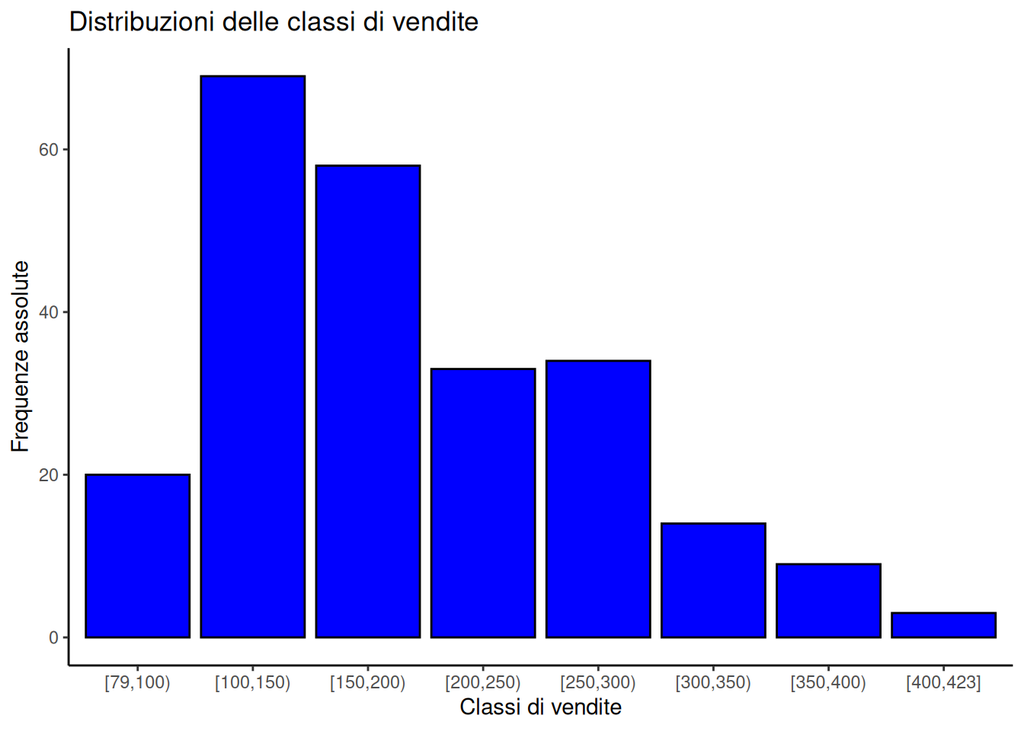

```r
ggplot(data = dati)+
  geom_bar(aes(x = sales_cl),
           stat = "count",
           col = "black",
           fill = "blue")+
  labs(title = "Distribuzioni delle classi di vendite",
       x = "Classi di vendite",
       y = "Frequenze assolute")+
  theme_classic()
```

```r
gini.index <- function(x){
  ni=table(x)
  fi=ni/length(x)
  fi2=fi^2
  J = length(table(x))

  gini = 1-sum(fi2)
  gini.normalizzato = gini/((J-1)/J)
  return(gini.normalizzato)
}

print(gini.index(dati$sales_cl), digits = 2)
```

```
## [1] 0.92
```

Il grafico a barre mostra una distribuzione con una frequenza maggiore nelle classi centrali e una coda verso destra, coerente con l’asimmetria positiva che avevamo visto negli indici descrittivi della variabile sales originale. Tuttavia, l’Indice di Eterogeneità di Gini elevato (0.92) indica che, nonostante questa forma, le frequenze tra le diverse classi di vendita non sono così sbilanciate da concentrare la maggior parte delle osservazioni in poche classi.  
C’è una distribuzione relativamente uniforme del numero di transazioni tra le diverse fasce di valore di vendita.

Tutto ciò però potrebbe dipendere dall’eccessiva perdita di informazione dovuta alla suddivisione in classi. Per prova si costruisce un suddivisioni con più classi (ampiezza 25 e non 50):

```r
dati$sales_cl <- cut(dati$sales, breaks = c(75, 100, 125, 150, 175, 200, 225, 250, 275, 300, 325, 350, 375, 400, 425), include.lowest = TRUE, right = FALSE)
#Per dividere in un numero di classi scelto da tastiera
#n <- as.integer(readline(prompt = "Inserisci un numero intero: "))
#dati$sales_cl <- cut(dati$sales, breaks = seq(75, 425, by = (425 - 75) / n), include.lowest = TRUE, right = FALSE)
kable(distr.freq("sales_cl", dati), caption = "Distribuzioni di frequenze di sales_cl", digits = 2)
```

Distribuzioni di frequenze di sales_cl

|  | ni | fi | Ni | Fi |
| --- | --- | --- | --- | --- |
| [75,100) | 20 | 0.08 | 20 | 0.08 |
| [100,125) | 37 | 0.15 | 57 | 0.24 |
| [125,150) | 32 | 0.13 | 89 | 0.37 |
| [150,175) | 30 | 0.12 | 119 | 0.50 |
| [175,200) | 28 | 0.12 | 147 | 0.61 |
| [200,225) | 18 | 0.07 | 165 | 0.69 |
| [225,250) | 15 | 0.06 | 180 | 0.75 |
| [250,275) | 15 | 0.06 | 195 | 0.81 |
| [275,300) | 19 | 0.08 | 214 | 0.89 |
| [300,325) | 8 | 0.03 | 222 | 0.92 |
| [325,350) | 6 | 0.03 | 228 | 0.95 |
| [350,375) | 7 | 0.03 | 235 | 0.98 |
| [375,400) | 2 | 0.01 | 237 | 0.99 |
| [400,425] | 3 | 0.01 | 240 | 1.00 |

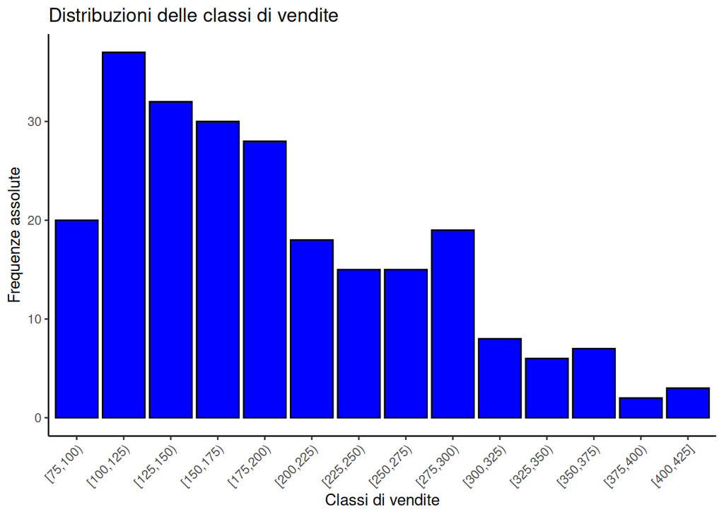

```r
ggplot(data = dati)+
  geom_bar(aes(x = sales_cl),
           stat = "count",
           col = "black",
           fill = "blue")+
  labs(title = "Distribuzioni delle classi di vendite",
       x = "Classi di vendite",
       y = "Frequenze assolute")+
  theme_classic()+
  theme(axis.text.x = element_text(angle = 45, hjust = 1))
```

```r
print(gini.index(dati$sales_cl), digits = 2)
```

```
## [1] 0.97
```

Sulla base di questi risultati, possiamo concludere che c’è una notevole eterogeneità nella distribuzione delle frequenze di sales una volta suddivisa in classi, anche con una granularità maggiore. Questo significa che il numero di osservazioni non è concentrato in modo schiacciante in poche fasce di vendita, ma è distribuito in modo abbastanza uniforme tra le diverse classi.

# 5. Calcolo della probabilità

**Qual è la probabilità che, presa una riga a caso di questo dataset, essa riporti la città “Beaumont”? E la probabilità che riporti il mese di Luglio? E la probabilità che riporti il mese di dicembre 2012?**

- In questa casistica possiamo usare la probabilità classica:
  - quindi numero di casi favorevoli su casi possibili.

```r
kable(table(dati$city)/N, col.names = c("City", "Prob") ,digits = 2)
```

| City | Prob |
| --- | --- |
| Beaumont | 0.25 |
| Bryan-College Station | 0.25 |
| Tyler | 0.25 |
| Wichita Falls | 0.25 |

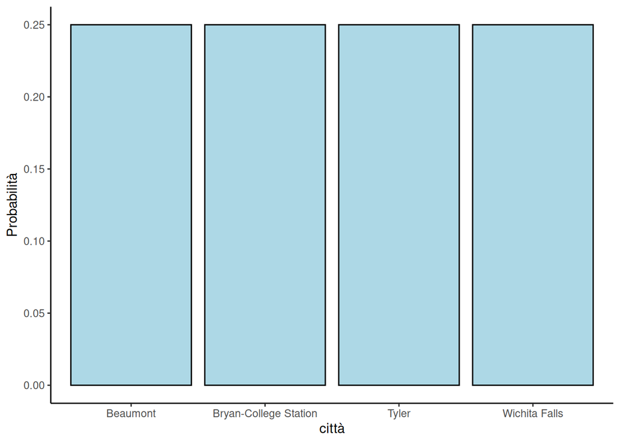

```r
ggplot(data = dati)+
  geom_bar(aes(x=city,
                     y=after_stat(count/sum(count))),
                 stat="count",
                 col="black",
                 fill="lightblue")+
  theme_classic()+
  labs(x="città",
       y="Probabilità")
```

Come si vede dal grafico tutte le città hanno uguale probabilità, che è precisamente di 0.25.

Stesso discorso vale per i mesi, con probabilità di 0.083.

```r
kable(table(dati$month)/N, col.names = c("Month", "Prob"), digits = 2)
```

| Month | Prob |
| --- | --- |
| January | 0.08 |
| February | 0.08 |
| March | 0.08 |
| April | 0.08 |
| May | 0.08 |
| June | 0.08 |
| July | 0.08 |
| August | 0.08 |
| September | 0.08 |
| October | 0.08 |
| November | 0.08 |
| December | 0.08 |

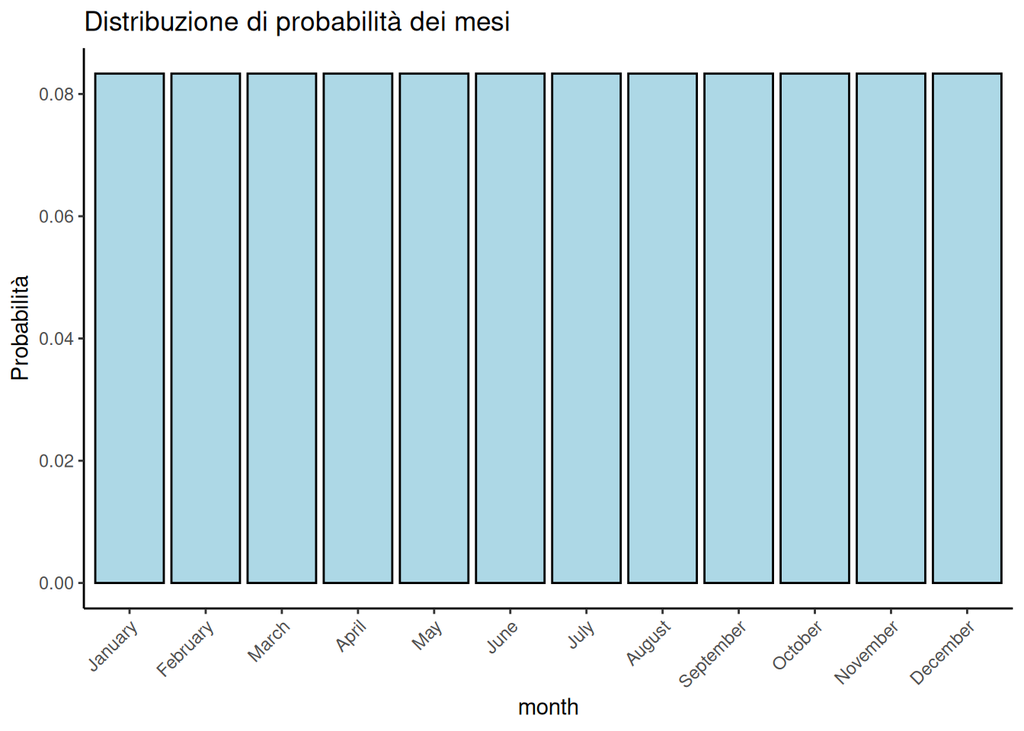

```r
ggplot(data = dati)+
  geom_bar(aes(x=month,
                     y=after_stat(count/sum(count))),
                 stat="count",
                 col="black",
                 fill="lightblue")+
  labs(title="Distribuzione di probabilità dei mesi",
       x="month",
       y="Probabilità")+
  theme_classic()+
  theme(axis.text.x = element_text(angle = 45, hjust = 1))
```

Possiamo vedere creando la tabella di contingenza con le variabili year e month che ogni mese relativo a un anno ha probabilità 0.016 ovvero 1.6%

```r
kable(table(dati$year, dati$month)/N)
```

|  | January | February | March | April | May | June | July | August | September | October | November | December |
| --- | --- | --- | --- | --- | --- | --- | --- | --- | --- | --- | --- | --- |
| 2010 | 0.0166667 | 0.0166667 | 0.0166667 | 0.0166667 | 0.0166667 | 0.0166667 | 0.0166667 | 0.0166667 | 0.0166667 | 0.0166667 | 0.0166667 | 0.0166667 |
| 2011 | 0.0166667 | 0.0166667 | 0.0166667 | 0.0166667 | 0.0166667 | 0.0166667 | 0.0166667 | 0.0166667 | 0.0166667 | 0.0166667 | 0.0166667 | 0.0166667 |
| 2012 | 0.0166667 | 0.0166667 | 0.0166667 | 0.0166667 | 0.0166667 | 0.0166667 | 0.0166667 | 0.0166667 | 0.0166667 | 0.0166667 | 0.0166667 | 0.0166667 |
| 2013 | 0.0166667 | 0.0166667 | 0.0166667 | 0.0166667 | 0.0166667 | 0.0166667 | 0.0166667 | 0.0166667 | 0.0166667 | 0.0166667 | 0.0166667 | 0.0166667 |
| 2014 | 0.0166667 | 0.0166667 | 0.0166667 | 0.0166667 | 0.0166667 | 0.0166667 | 0.0166667 | 0.0166667 | 0.0166667 | 0.0166667 | 0.0166667 | 0.0166667 |

# 6. Creazione di nuove variabili

**Crea una nuova colonna che calcoli il prezzo medio degli immobili utilizzando le variabili disponibili. Prova a creare una colonna che misuri l’efficacia degli annunci di vendita. Commenta e discuti i risultati.**

- Per il prezzo medio dei prodotti possiamo usare le variabili sales e volume facendo una media aritmetica, con la somma di tutte le vendite diviso il numero di vendite:

```r
dati$mean_price <- (dati$volume/dati$sales)*10^6
```

- Per capire invece l’efficacia degli annunci di vendita abbiamo bisogno di un valore espresso in percentuale. Possiamo provare a usare il numero di vendite e il numero di annunci attivi a fine mese, ovvero le variabili sales e listings:

```r
dati$efficacia <- dati$sales/dati$listings*100
```

Questo indice quantifica l’efficacia degli annunci di vendita come la percentuale di conversioni ottenute rispetto al numero di annunci attivi. Un valore superiore implica una maggiore performance degli annunci nel concretizzare vendite. Inoltre si potrebbe accoppiare questa metrica con month_inventory. Infatti month_inventoy guarda al futuro e stima quanto tempo ci vorrebbe per vendere l’intero inventario attuale al tasso di vendita corrente. Un valore basso di months_inventory indica un mercato con una forte domanda rispetto all’offerta, suggerendo che gli immobili vengono venduti rapidamente. Un alto tasso di sales/listings dovrebbe teoricamente portare a un basso months_inventory. Ma un mercato potrebbe avere un’alta sales/listings ma anche un alto months_inventory se c’è molta offerta ma quella esistente si vende bene. Viceversa, un basso months_inventory con una bassa sales/listings potrebbe indicare poca offerta ma anche una bassa capacità di conversione.

# 7. Analisi condizionata

**Usa il pacchetto dplyr o il linguaggio base di R per effettuare analisi statistiche condizionate per città, anno e mese. Genera dei summary (media, deviazione standard) e rappresenta graficamente i risultati.**

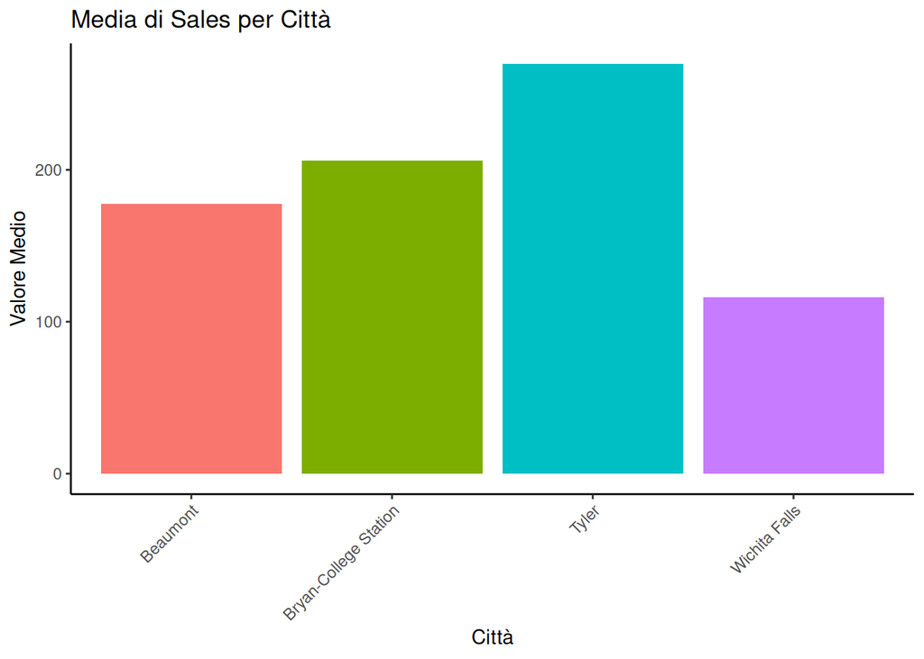

```r
#Per la variabile city
summary.città <- dati %>%
  group_by(city)%>%
  summarise(media_sales = mean(sales), dev.st.sales = sd(sales),
            media_volume = mean(volume), dev.st.volume = sd(volume))

ggplot(summary.città) +
  geom_col(aes(x = city, y = media_sales, fill = city)) +
  labs(title = "Media di Sales per Città",
       x = "Città",
       y = "Valore Medio") +
  theme_classic()+
  theme(axis.text.x = element_text(angle = 45, hjust = 1),
        legend.position = "none")
```

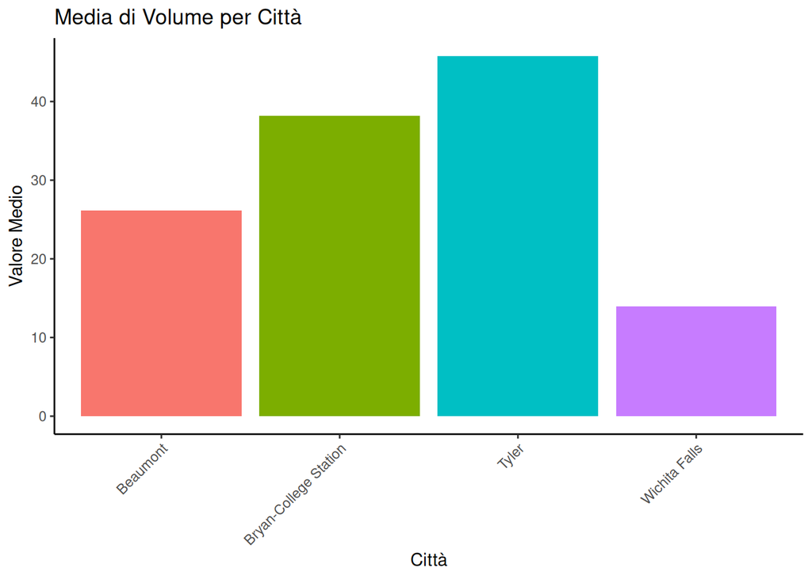

```r
ggplot(summary.città) +
  geom_col(aes(x = city, y = media_volume, fill = city)) +
  labs(title = "Media di Volume per Città",
       x = "Città",
       y = "Valore Medio") +
  theme_classic()+
  theme(axis.text.x = element_text(angle = 45, hjust = 1),
        legend.position = "none")
```

Vedendo i due grafici possiamo notare che sono molto simili, o meglio si distribuiscono in modo molto simile. Qusto potrebbe far intendere che alla fine il prezzo di vendita medio è molto simile tra le città e quindi che la differenza sta principalmente nel numero di vendite. Per capire meglio abbiamo bisogno però del prezzo medio:

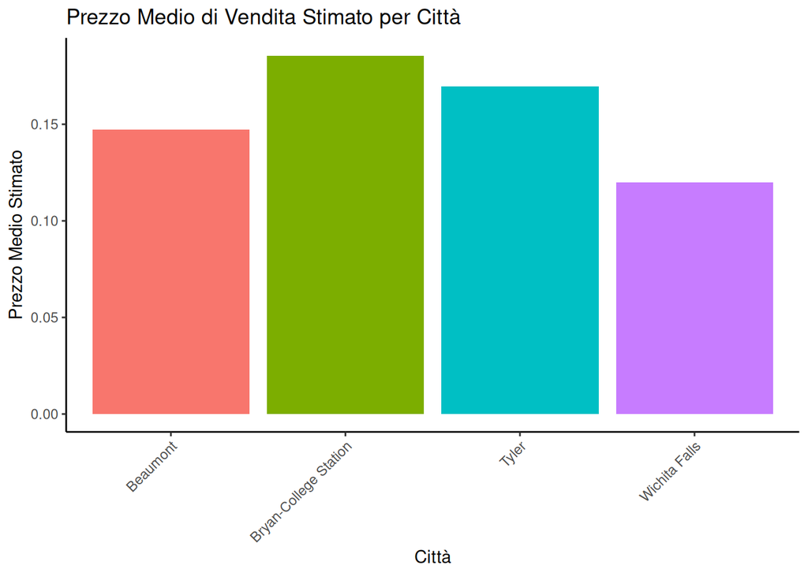

```r
summary.città <- summary.città %>%
   mutate(prezzo_medio_stimato = media_volume / media_sales)

ggplot(summary.città) +
  geom_col(aes(x = city, y = prezzo_medio_stimato, fill = city)) +
  labs(title = "Prezzo Medio di Vendita Stimato per Città",
       x = "Città",
       y = "Prezzo Medio Stimato",
       fill = "Città") +
  theme_classic()+
  theme(axis.text.x = element_text(angle = 45, hjust = 1),
        legend.position = "none")
```

In realtà vedendo il grafico possiamo vedere che le differenze nel volume totale delle vendite tra le città sono probabilmente influenzate sia dal numero di vendite che dal prezzo medio di vendita, come già intuito nell’analisi precedente della variabilità della variabile volume. Le città con un volume maggiore potrebbero avere sia un numero di vendite più alto che un prezzo medio di vendita leggermente superiore.

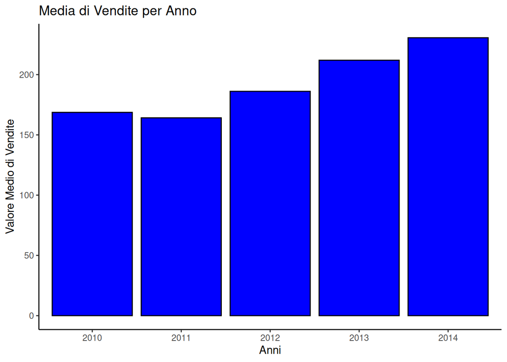

```r
#Per la variabile year
summary.year <- dati %>%
  group_by(year)%>%
  summarise(media_sales = mean(sales), dev.st.sales = sd(sales),
            media_volume = mean(volume), dev.st.volume = sd(volume))

ggplot(summary.year) +
  geom_col(aes(x = factor(year), y = media_sales),
           col="black",
           fill="blue") +
  labs(title = "Media di Vendite per Anno",
       x = "Anni",
       y = "Valore Medio di Vendite") +
  theme_classic()
```

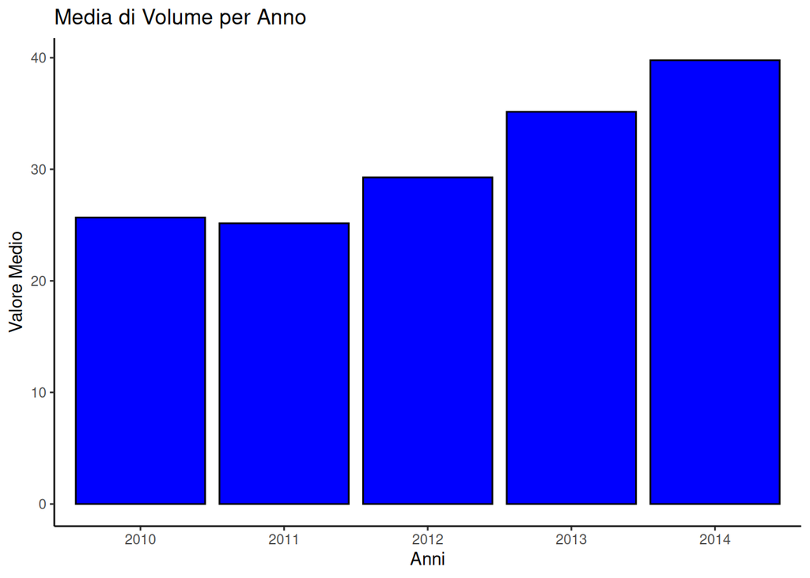

```r
ggplot(summary.year, aes(x = factor(year))) +
  geom_col(aes(y = media_volume,),
           col="black",
           fill="blue") +
  labs(title = "Media di Volume per Anno",
       x = "Anni",
       y = "Valore Medio") +
  theme_classic()
```

Si può notare una crescita negli anni sia delle vendite che del volume totale

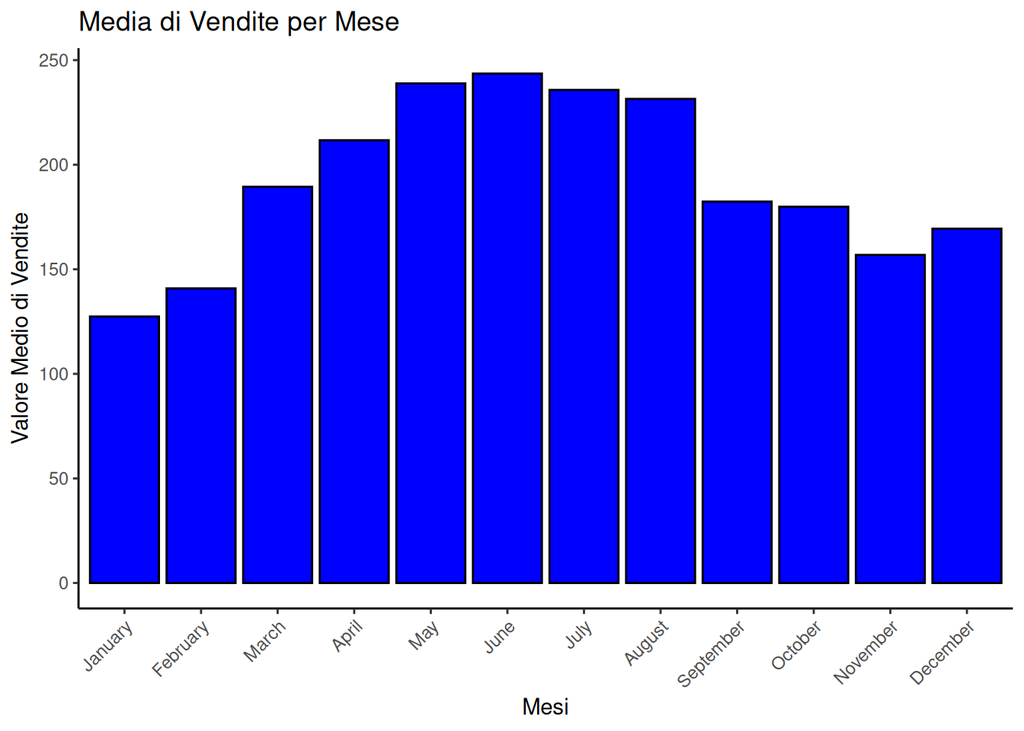

```r
#Per la variabile month
summary.month <- dati %>%
  group_by(month)%>%
  summarise(media_sales = mean(sales), dev.st.sales = sd(sales),
            media_volume = mean(volume), dev.st.volume = sd(volume))


ggplot(summary.month) +
  geom_col(aes(x = month, y =media_sales),
           col="black",
           fill="blue") +
  labs(title = "Media di Vendite per Mese",
       x = "Mesi",
       y = "Valore Medio di Vendite") +
  theme_classic()+
  theme(axis.text.x = element_text(angle = 45, hjust = 1))
```

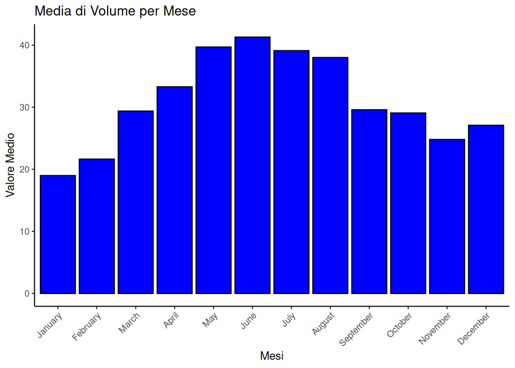

```r
ggplot(summary.month) +
  geom_col(aes(x = month, y = media_volume),
           col="black",
           fill="blue") +
  labs(title = "Media di Volume per Mese",
       x = "Mesi",
       y = "Valore Medio") +
  theme_classic()+
  theme(axis.text.x = element_text(angle = 45, hjust = 1))
```

Si può notare una miglior capacità di vendita nei periodi più caldi (primavera/estate).

# 8. Creazione di visualizzazioni con ggplot2

Utilizza ggplot2 per creare grafici personalizzati. Assicurati di esplorare:  
- Boxplot per confrontare la distribuzione del prezzo mediano tra le città.  
- Grafici a barre per confrontare il totale delle vendite per mese e città.  
- Line charts per confrontare l’andamento delle vendite in periodi storici differenti.

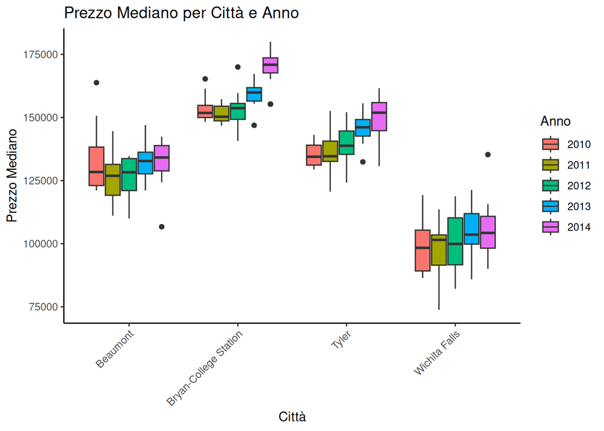

```r
#I boxplot
ggplot(dati, aes(x = city, y = median_price, fill = as.factor(year))) +
  geom_boxplot() +
  labs(title = "Prezzo Mediano per Città e Anno",
       x = "Città",
       y = "Prezzo Mediano",
       fill = "Anno") + # Etichetta per la leggenda 'fill'
  theme_classic() + # Un tema pulito per il grafico
  theme(axis.text.x = element_text(angle = 45, hjust = 1)) # Per ruotare le etichette dell'asse x se lunghe
```

I boxplot mostrano come Bryan-College Station ha i prezzi mediani più alti, seguita da Tyler. Beaumont si colloca a un livello intermedio, mentre Wichita Falls presenta i prezzi mediani più bassi.

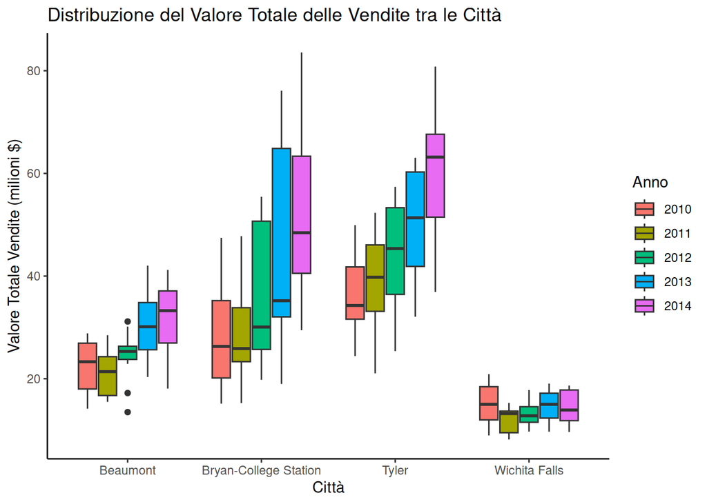

```r
ggplot(data = dati) +
  geom_boxplot(aes(x = city,
                   y = volume,
                   fill=as.factor(year))) +
  labs(title = "Distribuzione del Valore Totale delle Vendite tra le Città",
       x = "Città",
       y = "Valore Totale Vendite (milioni $)",
       fill = "Anno") +
  theme_classic()
```

In questo grafico invece Tyler e Bryan-College Station mostrano valori totali di vendita più elevati e una maggiore variabilità rispetto a Beaumont e, soprattutto, a Wichita Falls. In generale in questo grafico e in quello precedente si osserva una tendenza generale all’aumento del valore totale delle vendite nel corso degli anni analizzati, con una maggiore variabilità negli anni più recenti (2013 e 2014).

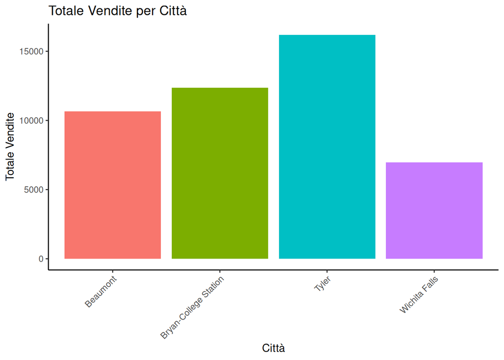

```r
#Raggruppa i dati per città e calcola il totale delle vendite
vendite_totali_citta <- dati %>%
  group_by(city) %>%
  summarize(totale_vendite = sum(sales, na.rm = TRUE)) %>%
  ungroup()

ggplot(vendite_totali_citta) +
  geom_col(aes(x = city, y = totale_vendite, fill = city)) +
  labs(title = "Totale Vendite per Città",
       x = "Città",
       y = "Totale Vendite") +
  theme_classic()+
  theme(axis.text.x = element_text(angle = 45, hjust = 1),
        legend.position = "none")
```

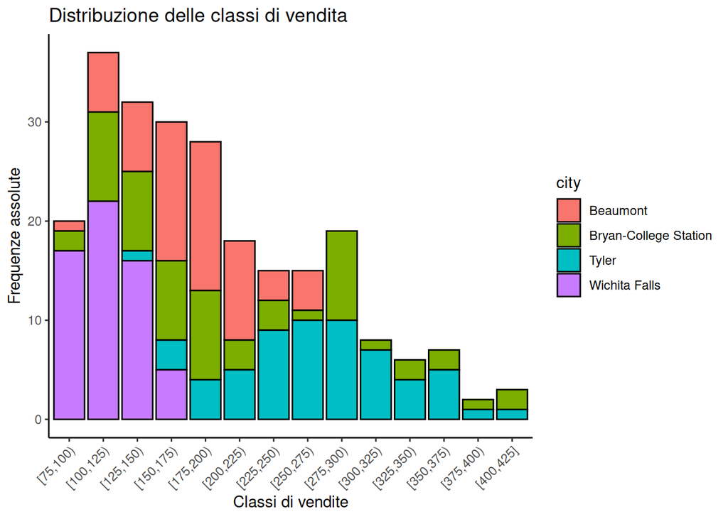

```r
ggplot(data = dati)+
  geom_bar(aes(x=sales_cl,
               fill = city),
           position = "stack",
           stat = "count",
           col = "black")+
  labs(title = "Distribuzione delle classi di vendita",
       x="Classi di vendite",
       y="Frequenze assolute")+
  theme_classic()+
  theme(axis.text.x = element_text(angle = 45, hjust = 1))
```

Questo grafico a barre sovrapposte fa vedere da un’altra prospettiva come effettivamente si distribuiscano i numeri di vendite tra le città.